# Practical Machine Learning Course Project

Miguel Ángel Sánchez

11/29/2020

## Overview

Using devices such as Jawbone Up, Nike FuelBand, and Fitbit it is now possible to collect a large amount of data about personal activity relatively inexpensively. These type of devices are part of the quantified self movement – a group of enthusiasts who take measurements about themselves regularly to improve their health, to find patterns in their behavior, or because they are tech geeks. One thing that people regularly do is quantify how much of a particular activity they do, but they rarely quantify how well they do it. In this project, your goal will be to use data from accelerometers on the belt, forearm, arm, and dumbell of 6 participants. They were asked to perform barbell lifts correctly and incorrectly in 5 different ways. More information is available from the website here: [link](http://web.archive.org/web/20161224072740/http:/groupware.les.inf.puc-rio.br/har) (see the section on the Weight Lifting Exercise Dataset).

## Data Loading and Processing

### Packages

```r
library(caret)
```

```r
library(corrplot)
library(DataExplorer)
library(dplyr)
library(gbm)
library(ggplot2)
library(randomForest)
library(rpart)
library(rpart.plot)
```

### Getting, Cleaning and Exploring the data

```r
url_train <- "https://d396qusza40orc.cloudfront.net/predmachlearn/pml-training.csv"
url_test <- "https://d396qusza40orc.cloudfront.net/predmachlearn/pml-testing.csv"
train <- read.csv(url_train, na.strings = c(NA, "NA", ""))
test <- read.csv(url_test, na.strings = c(NA, "NA", ""))
dim(train)
```

```
## [1] 19622   160
```

```r
dim(test)
```

```
## [1]  20 160
```

```r
str(train)
```

```
## 'data.frame':    19622 obs. of  160 variables:
##  $ X                       : int  1 2 3 4 5 6 7 8 9 10 ...
##  $ user_name               : chr  "carlitos" "carlitos" "carlitos" "carlitos" ...
##  $ raw_timestamp_part_1    : int  1323084231 1323084231 1323084231 1323084232 1323084232 1323084232 1323084232 1323084232 1323084232 1323084232 ...
##  $ raw_timestamp_part_2    : int  788290 808298 820366 120339 196328 304277 368296 440390 484323 484434 ...
##  $ cvtd_timestamp          : chr  "05/12/2011 11:23" "05/12/2011 11:23" "05/12/2011 11:23" "05/12/2011 11:23" ...
##  $ new_window              : chr  "no" "no" "no" "no" ...
##  $ num_window              : int  11 11 11 12 12 12 12 12 12 12 ...
##  $ roll_belt               : num  1.41 1.41 1.42 1.48 1.48 1.45 1.42 1.42 1.43 1.45 ...
##  $ pitch_belt              : num  8.07 8.07 8.07 8.05 8.07 8.06 8.09 8.13 8.16 8.17 ...
##  $ yaw_belt                : num  -94.4 -94.4 -94.4 -94.4 -94.4 -94.4 -94.4 -94.4 -94.4 -94.4 ...
##  $ total_accel_belt        : int  3 3 3 3 3 3 3 3 3 3 ...
##  $ kurtosis_roll_belt      : chr  NA NA NA NA ...
##  $ kurtosis_picth_belt     : chr  NA NA NA NA ...
##  $ kurtosis_yaw_belt       : chr  NA NA NA NA ...
```

[output cut: 86 more lines]

As shown below there are $19622$ observations and $160$ variables in the Train dataset

### Cleaning the input data

We remove the variables that contains missing values. Note along the cleaning process we display the dimension of the reduced dataset

```r
x = apply(train, 2, function(x) round((sum(is.na(x)) / length(x)) * 100, 2)) %>%
  as.data.frame() %>%
  tibble::rownames_to_column("names")
names(x) <- c("names", "na_s")
x %>% arrange(na_s) %>% filter(na_s > 0)
```

```
##                        names  na_s
## 1         kurtosis_roll_belt 97.93
## 2        kurtosis_picth_belt 97.93
## 3          kurtosis_yaw_belt 97.93
## 4         skewness_roll_belt 97.93
## 5       skewness_roll_belt.1 97.93
## 6          skewness_yaw_belt 97.93
## 7              max_roll_belt 97.93
## 8             max_picth_belt 97.93
## 9               max_yaw_belt 97.93
## 10             min_roll_belt 97.93
## 11            min_pitch_belt 97.93
## 12              min_yaw_belt 97.93
## 13       amplitude_roll_belt 97.93
## 14      amplitude_pitch_belt 97.93
```

[output cut: 86 more lines]

There are many variables with lost data so they are removed from the original data.

```r
names_nas <- filter(x, na_s > 0) %>% pull(names)
train <- select(train, -all_of(names_nas))
test <- select(test, -all_of(names_nas))
```

```r
# remove identification only variables (columns 1 to 5)
train <- train[, -c(1:5)]
test <- test[, -c(1:5)]
```

### Plot missing values

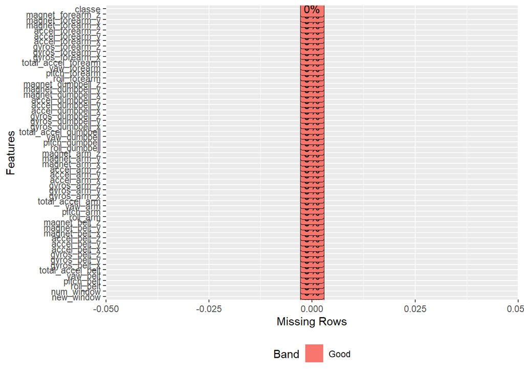

```r
plot_missing(train)
```

Removing the variables with values near zero, that means that they have not so much meaning in the predictions.

```r
nzv <- nearZeroVar(train, saveMetrics = TRUE)
train <- train[, nzv$nzv == FALSE] %>% mutate(classe = factor(classe))

test <- test[, nzv$nzv==FALSE]
```

### Correlation Analysis

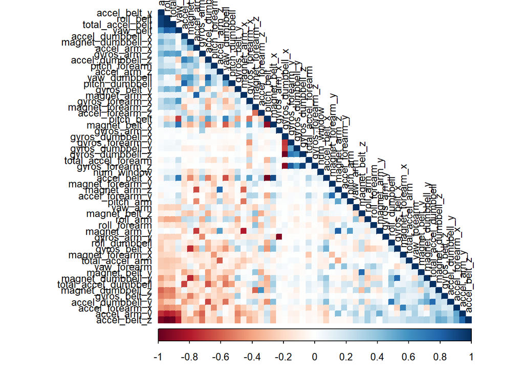

```r
corMatrix <- cor(train[, -54])
corrplot(corMatrix, order = "FPC", method = "color", type = "lower",
         tl.cex = 0.8, tl.col = rgb(0, 0, 0))
```

we eliminate the high correlations

```r
descrCor <- cor(train[, -54])
highlyCorDescr <- findCorrelation(descrCor, cutoff = .75)
train <- train[,-highlyCorDescr]
```

### Create cross validation set

```r
set.seed(2020)

inTrain = createDataPartition(train$classe, p = 3/4, list=FALSE)
training = train[inTrain, ]
crossValidation = train[-inTrain, ]
```

### Train model

Train model with random forest due to its highly accuracy rate.

```r
set.seed(2020)
modFit <- train(
  classe ~ ., method="rf", data = train,
  trControl = trainControl(method="cv", number=3, verboseIter=FALSE)
)
summary(modFit)
```

```
##                 Length Class      Mode
## call                4  -none-     call
## type                1  -none-     character
## predicted       19622  factor     numeric
## err.rate         3000  -none-     numeric
## confusion          30  -none-     numeric
## votes           98110  matrix     numeric
## oob.times       19622  -none-     numeric
## classes             5  -none-     character
## importance         32  -none-     numeric
## importanceSD        0  -none-     NULL
## localImportance     0  -none-     NULL
## proximity           0  -none-     NULL
## ntree               1  -none-     numeric
## mtry                1  -none-     numeric
## forest             14  -none-     list
## y               19622  factor     numeric
## test                0  -none-     NULL
## inbag               0  -none-     NULL
## xNames             32  -none-     character
## problemType         1  -none-     character
## tuneValue           1  data.frame list
## obsLevels           5  -none-     character
## param               0  -none-     list
```

### Accuracy on training set and cross validation set

#### Training set:

```r
trainingPred <- predict(modFit, training)
confusionMatrix(trainingPred, training$classe)
```

```
## Confusion Matrix and Statistics
##
##           Reference
## Prediction    A    B    C    D    E
##          A 4185    0    0    0    0
##          B    0 2848    0    0    0
##          C    0    0 2567    0    0
##          D    0    0    0 2412    0
##          E    0    0    0    0 2706
##
## Overall Statistics
##
##                Accuracy : 1
##                  95% CI : (0.9997, 1)
##     No Information Rate : 0.2843
##     P-Value [Acc > NIR] : < 2.2e-16
##
##                   Kappa : 1
##
##  Mcnemar's Test P-Value : NA
##
## Statistics by Class:
##
##                      Class: A Class: B Class: C Class: D Class: E
## Sensitivity            1.0000   1.0000   1.0000   1.0000   1.0000
## Specificity            1.0000   1.0000   1.0000   1.0000   1.0000
## Pos Pred Value         1.0000   1.0000   1.0000   1.0000   1.0000
## Neg Pred Value         1.0000   1.0000   1.0000   1.0000   1.0000
## Prevalence             0.2843   0.1935   0.1744   0.1639   0.1839
## Detection Rate         0.2843   0.1935   0.1744   0.1639   0.1839
## Detection Prevalence   0.2843   0.1935   0.1744   0.1639   0.1839
## Balanced Accuracy      1.0000   1.0000   1.0000   1.0000   1.0000
```

#### Cross validation set

```r
cvPred <- predict(modFit, crossValidation)
confusionMatrix(cvPred, crossValidation$classe)
```

```
## Confusion Matrix and Statistics
##
##           Reference
## Prediction    A    B    C    D    E
##          A 1395    0    0    0    0
##          B    0  949    0    0    0
##          C    0    0  855    0    0
##          D    0    0    0  804    0
##          E    0    0    0    0  901
##
## Overall Statistics
##
##                Accuracy : 1
##                  95% CI : (0.9992, 1)
##     No Information Rate : 0.2845
##     P-Value [Acc > NIR] : < 2.2e-16
##
##                   Kappa : 1
##
##  Mcnemar's Test P-Value : NA
##
## Statistics by Class:
##
##                      Class: A Class: B Class: C Class: D Class: E
## Sensitivity            1.0000   1.0000   1.0000   1.0000   1.0000
## Specificity            1.0000   1.0000   1.0000   1.0000   1.0000
## Pos Pred Value         1.0000   1.0000   1.0000   1.0000   1.0000
## Neg Pred Value         1.0000   1.0000   1.0000   1.0000   1.0000
## Prevalence             0.2845   0.1935   0.1743   0.1639   0.1837
## Detection Rate         0.2845   0.1935   0.1743   0.1639   0.1837
## Detection Prevalence   0.2845   0.1935   0.1743   0.1639   0.1837
## Balanced Accuracy      1.0000   1.0000   1.0000   1.0000   1.0000
```

### RESULTS

Predictions on the real testing set

```r
testingPred <- predict(modFit, test)
testingPred
```

```
##  [1] B A B A A E D B A A B C B A E E A B B B
## Levels: A B C D E
```